# Exercise 2 – Regression

[Introduction to Machine Learning](https://slds-lmu.github.io/i2ml/)

Show All Solutions

Only R | Only Python | Print

**Hint: Useful libraries**

**R**

```r
# Consider the following libraries for this exercise sheet:

library(ggplot2)
library(mlr3verse)
library(mlr3learners)
library(mlr3viz)
library(quantreg)
```

**Python**

```python
# Consider the following libraries for this exercise sheet:

# general
import numpy as np
import pandas as pd
import math

# plots
import matplotlib.pyplot as plt
import seaborn as sns

# sklearn
from sklearn.datasets import load_iris
from sklearn.tree import DecisionTreeRegressor
from sklearn.linear_model import LinearRegression
import sklearn.metrics as metrics
from sklearn.metrics import mean_absolute_error
```

## Exercise 1: Loss functions for regression tasks

**NoteLearning goals**

1. Assess how outliers affect models for different loss functions
2. Derive impact of a loss function from visual representation

In this exercise, we will examine loss functions for regression tasks somewhat more in depth.

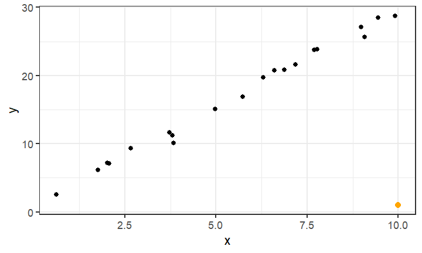

1. Consider the above linear regression task. How will the model parameters be affected by adding the new outlier point (orange) if you use $L1$ loss and $L2$ loss, respectively, in the empirical risk? (You do not need to actually compute the parameter values.)

**Solution**

$L2$ loss penalizes vertical distances to the regression line *quadratically*, while $L1$ only considers the *absolute* distance. As the outlier point lies pretty far from the remaining training data, it will have a large loss with $L2$, and the regression line will pivot to the bottom right to minimize the resulting empirical risk. A model trained with $L1$ loss is less susceptible to the outlier and will adjust only slightly to the new data.

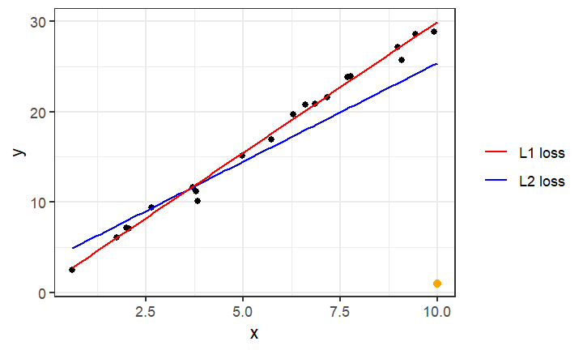

2. The second plot visualizes another loss function popular in regression tasks, the so-called *Huber loss* (depending on $\epsilon > 0$; here: $\epsilon = 5$). Describe how the Huber loss deals with residuals as compared to $L1$ and $L2$ loss. Can you guess its definition?

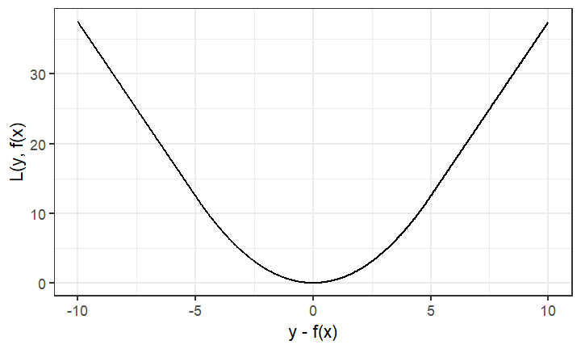

**Solution**

The Huber loss combines the respective advantages of $L1$ and $L2$ loss: it is smooth and (once) differentiable like $L2$ but does not punish larger residuals as severely, leading to more robustness. It is simply a (weighted) piecewise combination of both losses, where $\epsilon$ marks where $L2$ transits to $L1$ loss. The exact definition is:

$$L\left(y, f(\mathbf{x})\right)= \begin{cases}
\frac{1}{2}(y - f(\mathbf{x}))^2 & \text{ if } |y - f(\mathbf{x})|\le \epsilon \\
\epsilon |y - f(\mathbf{x})|-\frac{1}{2}\epsilon^2 \quad & \text{ otherwise }
\end{cases}, \quad \epsilon > 0$$

In the plot we can see how the parabolic shape of the loss around 0 evolves into an absolute-value function at $|y - f(\mathbf{x})|> \epsilon = 5$.

**Illustration: $L1$, $L2$, and Huber loss side by side**

To tie a) and b) together, we revisit the regression task from a) and add the model fitted with Huber loss. Like $L1$, the Huber model barely reacts to the outlier – its line stays close to the robust $L1$ fit (here the two practically coincide), whereas $L2$ is visibly dragged towards the outlier in the bottom right. Huber thus inherits the robustness of $L1$ while – being differentiable everywhere (recall its smooth shape in b) – remaining easy to optimize.

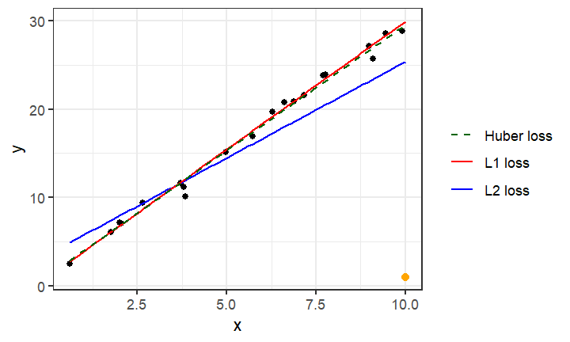

## Exercise 2: HRO in coding frameworks

**NoteLearning goals**

1. Translate lecture concepts to code
2. Evaluate a model using a custom loss function

Throughout the lecture, we will frequently use the `R` package `mlr3`, resp. the `Python` package `sklearn`, and its descendants, providing an integrated ecosystem for all common machine learning tasks. Let’s recap the HRO principle and see how it is reflected in either `mlr3` or `sklearn`. An overview of the most important objects and their usage, illustrated with numerous examples, can be found at [the `mlr3` book](https://mlr3book.mlr-org.com/) and [the `scikit` documentation](https://scikit-learn.org/stable/index.html).

1. How are the key concepts (i.e., hypothesis space, risk and optimization) you learned about in the lecture videos implemented?

**Solution**

**R**

```r
# H: First, initialize your learner.
# Before training learners just contain information on the functional form of f.
model <- lrn("regr.lm")
print(model)
x <- seq(0, 8, by = 0.01)
set.seed(42)
y <- -1 + 3 * x + rnorm(mean = 0, sd = 4, n = length(x))
dt <- data.frame(x = x, y = y)
task <- TaskRegr$new(id = "mytask", backend = dt, target = "y")
# R: `mlr3` relies on package-specific learning objectives.
# O: Optimization is triggered by `model$train()`, internally calling
# package-specific optimization procedures.
model$train(task)
sprintf("Model MSE: %.4f", model$predict_newdata(dt)$score())
```

```
<LearnerRegrLM:regr.lm>: Linear Model
* Model: -
* Parameters: list()
* Packages: mlr3, mlr3learners, stats
* Predict Types:  [response], se
* Feature Types: logical, integer, numeric, character, factor
* Properties: loglik, weights
```

'Model MSE: 15.1048'

**Python**

```python
# H: First, initialize your learner.
# Before training learners just contain information on the functional form of f.
model = LinearRegression(fit_intercept=True)
print(model)
x = np.arange(0, 8, 0.01)
np.random.seed(42)
y = -1 + 3 * x + np.random.normal(loc=0.0, scale=4, size=len(x))
# R: `sklearn` relies on package-specific learning objectives.
# O: Optimization is triggered by `model.fit()`, internally calling
# package-specific optimization procedures.
# within the function `model.fit()`:
model.fit(x.reshape(-1, 1), y)  # reshape for one feature design matrix
mse = metrics.mean_squared_error(y, model.predict(x.reshape(-1, 1)))
print(f"Model MSE: {mse:.4f}")
```

```
LinearRegression()
Model MSE: 15.4618
```

2. Have a look at `mlr3::tsk("iris")` / `sklearn.datasets.load_iris`. What attributes does this object store?

**Solution**

**R**

```r
task_iris <- tsk("iris")
sprintf("Feature names: %s", task_iris$feature_names)
sprintf("Target name: %s", task_iris$target_names)
```

1. 'Feature names: Petal.Length'

2. 'Feature names: Petal.Width'

3. 'Feature names: Sepal.Length'

4. 'Feature names: Sepal.Width'

'Target name: Species'

**Python**

```python
iris = load_iris()  # function to import iris as type "utils.Bunch" with sklearn
X = iris.data
y = iris.target
feature_names = iris.feature_names
target_names = iris.target_names
print("Type of object iris:", type(iris))
print("Feature names:"), [print(f"{i}") for i in feature_names]
print("Target names:", target_names)
print("\nShape of X and y\n", X.shape, y.shape)
print("\nType of X and y\n", type(X), type(y))
```

```
Type of object iris: <class 'sklearn.utils._bunch.Bunch'>
Feature names:
sepal length (cm)
sepal width (cm)
petal length (cm)
petal width (cm)
Target names: ['setosa' 'versicolor' 'virginica']

Shape of X and y
 (150, 4) (150,)

Type of X and y
 <class 'numpy.ndarray'> <class 'numpy.ndarray'>
```

3. Instantiate a regression tree learner (`lrn("regr.rpart")` / `DecisionTreeRegressor`). What are the different settings for this learner?

   **Hint**

   **R**

   `mlr3::mlr_learners$keys()` shows all available learners.

   **Python**

   Use `get_params()` to see all available settings.

**Solution**

**R**

```r
# List available learners in base mlr3 package
head(mlr_learners$keys())

# Inspect regression tree learner
lrn("regr.rpart")
```

1. 'classif.cv_glmnet'

2. 'classif.debug'

3. 'classif.featureless'

4. 'classif.glmnet'

5. 'classif.kknn'

6. 'classif.lda'

```
<LearnerRegrRpart:regr.rpart>: Regression Tree
* Model: -
* Parameters: xval=0
* Packages: mlr3, rpart
* Predict Types:  [response]
* Feature Types: logical, integer, numeric, factor, ordered
* Properties: importance, missings, selected_features, weights
```

```r
# List configurable hyperparameters (selected columns for readability)
as.data.table(lrn("regr.rpart")$param_set)[, .(id, class, lower, upper, default)]
```

```
                id    class lower upper        default
            <char>   <char> <num> <num>         <list>
 1:             cp ParamDbl     0     1           0.01
 2:     keep_model ParamLgl    NA    NA          FALSE
 3:     maxcompete ParamInt     0   Inf              4
 4:       maxdepth ParamInt     1    30             30
 5:   maxsurrogate ParamInt     0   Inf              5
 6:      minbucket ParamInt     1   Inf <NoDefault[0]>
 7:       minsplit ParamInt     1   Inf             20
 8: surrogatestyle ParamInt     0     1              0
 9:   usesurrogate ParamInt     0     2              2
10:           xval ParamInt     0   Inf             10
```

**Python**

```python
# Inspect regression tree learner
rtree = DecisionTreeRegressor()  # default setting
print(rtree)

# List configurable hyperparameters
[print(f"{k}: {v}") for k, v in rtree.get_params().items()][0]
```

```
DecisionTreeRegressor()
ccp_alpha: 0.0
criterion: squared_error
max_depth: None
max_features: None
max_leaf_nodes: None
min_impurity_decrease: 0.0
min_samples_leaf: 1
min_samples_split: 2
min_weight_fraction_leaf: 0.0
random_state: None
splitter: best
```

4. In Exercise 1, you encountered the *Huber loss*. Unlike $L1$ and $L2$ loss, it is not shipped as a ready-made loss/measure in either `mlr3` or `sklearn`. An implementation (following the definition from Exercise 1) is provided below. Use it to compute the empirical Huber risk (the mean Huber loss over all residuals) of the linear model from a). How does it compare to the MSE, and what does the difference tell you about how the two measures treat large residuals? In `sklearn`, you can wrap the loss into a custom scorer via `make_scorer`.

**R**

```r
# Given: the Huber loss (neither mlr3 nor sklearn ships it out of the box).
# It behaves like L2 loss for small residuals (|r| <= epsilon) and like L1 for
# large ones, combining smoothness with robustness to outliers.
huber_loss <- function(residual, epsilon = 1) {
  ifelse(
    abs(residual) <= epsilon,
    0.5 * residual^2,
    epsilon * abs(residual) - 0.5 * epsilon^2
  )
}
```

**Python**

```python
# Given: the Huber loss (neither mlr3 nor sklearn ships it out of the box).
# It behaves like L2 loss for small residuals (|r| <= epsilon) and like L1 for
# large ones, combining smoothness with robustness to outliers.
def huber_loss(residual, epsilon=1.0):
    residual = np.asarray(residual, dtype=float)
    is_small = np.abs(residual) <= epsilon
    return np.where(
        is_small,
        0.5 * residual**2,
        epsilon * np.abs(residual) - 0.5 * epsilon**2,
    )
```

**Solution**

**R**

```r
# The empirical Huber risk is just the mean Huber loss over all residuals, so
# we can evaluate our custom loss directly on the model's predictions -- no need
# to implement a full mlr3 measure. We reuse the LM and task from a).
pred <- model$predict(task)
huber_risk <- mean(huber_loss(pred$truth - pred$response, epsilon = 1))

cat(sprintf("Huber risk: %.4f\n", huber_risk))
cat(sprintf("MSE:        %.4f\n", pred$score(msr("regr.mse"))))
```

```
Huber risk: 2.6203
MSE:        15.1048
```

**Python**

```python
# In sklearn, any loss can be turned into a custom scorer. The empirical Huber
# risk is the mean Huber loss over the residuals. We reuse the LM from a).
from sklearn.metrics import make_scorer

def huber_risk(y_true, y_pred, epsilon=1.0):
    return huber_loss(y_true - y_pred, epsilon).mean()

# greater_is_better=False flips the sign (sklearn maximizes), so negate it back.
huber_scorer = make_scorer(huber_risk, greater_is_better=False)
risk = -huber_scorer(model, x.reshape(-1, 1), y)

print(f"Huber risk: {risk:.4f}")
print(f"MSE:        {mse:.4f}")
```

```
Huber risk: 2.6614
MSE:        15.4618
```

Both measures score the *same* model, but weight errors differently: the MSE ($\approx 15$) squares the residuals and is therefore dominated by the largest ones, whereas the Huber risk ($\approx 2.6$) grows only linearly beyond $\epsilon$ and keeps their influence in check. The comparison thus turns the robustness we saw visually in Exercise 1 into a concrete number – large residuals count for much less under Huber than under $L2$.

The R and Python values differ slightly because the synthetic data in a) is drawn with each language’s own random number generator: the same seed does not produce the same sample in R and Python, so the two models are fitted to (slightly) different data.

## Exercise 3: Polynomial regression

**TipThe whole exercise is only for lecture group A!**

**NoteLearning goals**

1. Express HRO components for polynomial regression
2. Derive gradient update for optimization
3. Analyze and discuss learner flexibility

Assume the following (noisy) data-generating process from which we have observed 50 realizations:
$$y = -3 + 5 \cdot \sin(0.4 \pi x) + \epsilon$$
with $\epsilon \, \sim \mathcal{N}(0, 1)$.

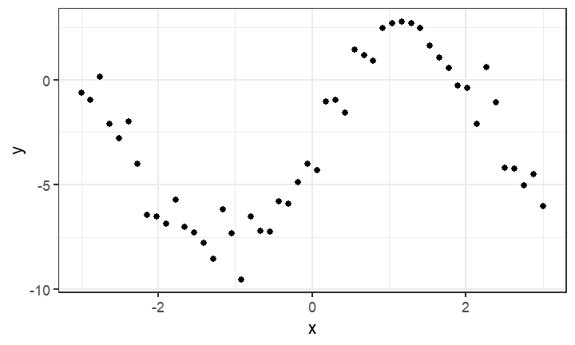

1. We decide to model the data with a cubic polynomial (including intercept term). State the corresponding hypothesis space.

**Solution**

Cubic means degree 3, so our hypothesis space will look as follows:

$$\mathcal{H}= \{ f(\mathbf{x}~|~ \boldsymbol{\theta})= \theta_0 + \theta_1 x + \theta_2 x^2 + \theta_3 x^3
~|~ (\theta_0, \theta_1, \theta_2, \theta_3)^\top \in \mathbb{R}^4 \}$$

2. State the empirical risk w.r.t. $\boldsymbol{\theta}$ for a member of the hypothesis space. Use $L2$ loss and be as explicit as possible.

**Solution**

The empirical risk is:

$$\mathcal{R}_{\text{emp}}(\boldsymbol{\theta})= \sum_{i = 1}^{50} \left(y^{(i)}- \left[ \theta_0 + \theta_1 x^{(i)} +
\theta_2 \left( x^{(i)} \right)^2 + \theta_3 \left( x^{(i)} \right)^3 \right]
\right)^2$$

3. We can minimize this risk using gradient descent. Derive the gradient of the empirical risk w.r.t $\boldsymbol{\theta}$.

**Solution**

We can find the gradient just as we did for an intermediate result when we derived the least-squares estimator:

$$\begin{align*}
\nabla_{\boldsymbol{\theta}} \mathcal{R}_{\text{emp}}(\boldsymbol{\theta})&=
\frac{\partial{}}{\partial \boldsymbol{\theta}} \left \| \mathbf{y}- \mathbf{X}\boldsymbol{\theta}\right \|_2^2 \\
&= \frac{\partial{}}{\partial \boldsymbol{\theta}} \left( \left(\mathbf{y}- \mathbf{X}\boldsymbol{\theta}\right)^\top
\left(\mathbf{y}- \mathbf{X}\boldsymbol{\theta}\right) \right) \\
&= - 2 \mathbf{y}^\top \mathbf{X}+ 2 \boldsymbol{\theta}^\top \mathbf{X}^\top \mathbf{X}\\
&= 2 \cdot \left(-\mathbf{y}^\top \mathbf{X}+ \boldsymbol{\theta}^\top \mathbf{X}^\top \mathbf{X}\right)
\end{align*}$$

4. Using the result for the gradient, explain how to update the current parameter $\boldsymbol{\theta}^{[t]}$ in a step of gradient descent.

**Solution**

Recall that the idea of gradient descent (!) is to traverse the risk surface in the direction of the gradient as we are in search for the minimum. Therefore, we will update our current parameter set $\boldsymbol{\theta}^{[t]}$ with the negative gradient of the current empirical risk w.r.t. $\boldsymbol{\theta}$, scaled by learning rate (or step size) $\alpha$:

$$\boldsymbol{\theta}^{[t +1]}= \boldsymbol{\theta}^{[t]}- \alpha \cdot \nabla_{\boldsymbol{\theta}} \mathcal{R}_{\text{emp}}(\boldsymbol{\theta}^{[t]}).$$

In order to see what that means it is helpful to recall that the gradient $\nabla_{\boldsymbol{\theta}} \mathcal{R}_{\text{emp}}(\boldsymbol{\theta})$ tells us about the effect (infinitesimally small) changes in $\boldsymbol{\theta}$ have on $\mathcal{R}_{\text{emp}}(\boldsymbol{\theta})$. Therefore, gradient updates focus on influential components, and we proceed more quickly along the important dimensions.

5. You will not be able to fit the data perfectly with a cubic polynomial. Describe the advantages and disadvantages that a more flexible model class would have. Would you opt for a more flexible learner?

**Solution**

- We would be able to trace the observations more closely if our function were less smooth, and thus reduce empirical risk. On the other hand, flexibility also has drawbacks:
- Flexible model classes often have more parameters, making training harder.
- We might run into a phenomenon called *overfitting*. Recall that our ultimate goal is to make predictions on *new* observations. However, fitting every quirk of the training observations – possibly caused by imprecise measurement or other factors of randomness/error – will not generalize so well to new data.

In the end, we need to balance model fit and generalization. We will discuss the choice of hypotheses quite a lot since it is one of the most crucial design decisions in machine learning.

## Exercise 4: Fitting a linear model by hand

**TipThe whole exercise is only for lecture group B!**

**NoteLearning goals**

1. Compute the least-squares estimator on a small example by hand
2. Interpret linear model coefficients
3. Predict with a fitted linear model

In the lecture, you saw that a linear model with $L2$ loss has a closed-form solution – the *ordinary-least-squares (OLS)* estimator
$$\boldsymbol{\hat\theta}= (\mathbf{X}^\top \mathbf{X})^{-1} \mathbf{X}^\top \mathbf{y},$$
where $\mathbf{X}$ is the design matrix (the feature columns padded with a leading column of ones for the intercept) and $\mathbf{y}$ the vector of observed targets. Consider the following small dataset with a single feature $x$ and target $y$:

| $i$ | $x^{(i)}$ | $y^{(i)}$ |
| --- | --- | --- |
| 1 | $-3$ | $1$ |
| 2 | $-1$ | $1$ |
| 3 | $1$ | $3$ |
| 4 | $3$ | $7$ |

We model it with a simple linear regression $f(x) = \theta_0 + \theta_1 x$.

1. Set up the design matrix $\mathbf{X}$ and compute the OLS estimator $\boldsymbol{\hat\theta}= (\hat{\theta}_0, \hat{\theta}_1)^\top$ by hand.

   **Hint**

   The feature is centered ($\sum_i x^{(i)} = 0$), which makes $\mathbf{X}^\top \mathbf{X}$ diagonal and hence trivial to invert.

**Solution**

With the intercept column, the design matrix and target vector are
$$\mathbf{X}= \begin{pmatrix} 1 & -3 \\ 1 & -1 \\ 1 & 1 \\ 1 & 3 \end{pmatrix}, \qquad
\mathbf{y}= \begin{pmatrix} 1 \\ 1 \\ 3 \\ 7 \end{pmatrix}.$$

We assemble the two ingredients of the OLS estimator:
$$\mathbf{X}^\top \mathbf{X}=
\begin{pmatrix} n & \sum_i x^{(i)} \\ \sum_i x^{(i)} & \sum_i \left(x^{(i)}\right)^2 \end{pmatrix}
= \begin{pmatrix} 4 & 0 \\ 0 & 20 \end{pmatrix},
\qquad
\mathbf{X}^\top \mathbf{y}=
\begin{pmatrix} \sum_i y^{(i)} \\ \sum_i x^{(i)} y^{(i)} \end{pmatrix}
= \begin{pmatrix} 12 \\ 20 \end{pmatrix}.$$

Because the feature is centered ($\sum_i x^{(i)} = 0$), $\mathbf{X}^\top \mathbf{X}$ is diagonal, so its inverse simply inverts the diagonal entries:
$$\left(\mathbf{X}^\top \mathbf{X}\right)^{-1} = \begin{pmatrix} \tfrac{1}{4} & 0 \\ 0 & \tfrac{1}{20} \end{pmatrix}.$$

Hence
$$\boldsymbol{\hat\theta}= \left(\mathbf{X}^\top \mathbf{X}\right)^{-1} \mathbf{X}^\top \mathbf{y}
= \begin{pmatrix} \tfrac{1}{4} & 0 \\ 0 & \tfrac{1}{20} \end{pmatrix}
\begin{pmatrix} 12 \\ 20 \end{pmatrix}
= \begin{pmatrix} 3 \\ 1 \end{pmatrix},$$
so the fitted model is $f(x) = 3 + x$.

2. Interpret the two fitted coefficients $\hat{\theta}_0$ and $\hat{\theta}_1$.

**Solution**

- Intercept $\hat{\theta}_0 = 3$: the predicted target when $x = 0$. As the feature is centered, $x = 0$ is the mean feature value, so the intercept here coincides with the mean target $\bar{y} = \tfrac{1}{4}(1 + 1 + 3 + 7) = 3$.
- Slope $\hat{\theta}_1 = 1$: the *marginal effect* of the feature – increasing $x$ by one unit increases the predicted target by one unit (ceteris paribus).
3. Use the fitted model to predict the target for a new observation with $x = 2$.

**Solution**

$$\hat{y} = \hat{\theta}_0 + \hat{\theta}_1 \cdot 2 = 3 + 1 \cdot 2 = 5.$$

## Exercise 5: Predicting `abalone`

**TipBonus exercise – will not be discussed in the tutorial session**

This optional exercise is meant for both lecture groups.

**NoteLearning goals**

1. Implement a regression model
2. Interpret linear model coefficients
3. Analyze basic regression fit

We want to predict the age of an abalone using its longest shell measurement and its weight. The `abalone` data can be found here: https://archive.ics.uci.edu/ml/machine-learning-databases/abalone/abalone.data.

Prepare the data as follows:

**R**

```r
# Download data
url <- "https://archive.ics.uci.edu/ml/machine-learning-databases/abalone/abalone.data"
abalone <- read.table(url, sep = ",", row.names = NULL)
colnames(abalone) <- c(
  "sex",
  "longest_shell",
  "diameter",
  "height",
  "whole_weight",
  "shucked_weight",
  "visceral_weight",
  "shell_weight",
  "rings"
)

# Reduce to relevant columns
abalone <- abalone[, c("longest_shell", "whole_weight", "rings")]
```

**Python**

```python
# load data from url

url = "https://archive.ics.uci.edu/ml/machine-learning-databases/abalone/abalone.data"
abalone = pd.read_csv(
    url,
    sep=",",
    names=[
        "sex",
        "longest_shell",
        "diameter",
        "height",
        "whole_weight",
        "shucked_weight",
        "visceral_weight",
        "shell_weight",
        "rings",
    ],
)

abalone = abalone[["longest_shell", "whole_weight", "rings"]]
print(abalone.head)
```

```
<bound method NDFrame.head of       longest_shell  whole_weight  rings
0             0.455        0.5140     15
1             0.350        0.2255      7
2             0.530        0.6770      9
3             0.440        0.5160     10
4             0.330        0.2050      7
...             ...           ...    ...
4172          0.565        0.8870     11
4173          0.590        0.9660     10
4174          0.600        1.1760      9
4175          0.625        1.0945     10
4176          0.710        1.9485     12

[4177 rows x 3 columns]>
```

1. Plot `LongestShell` and `WholeWeight` on the $x$- and $y$-axis, respectively, and color points according to `Rings`.

**Solution**

**R**

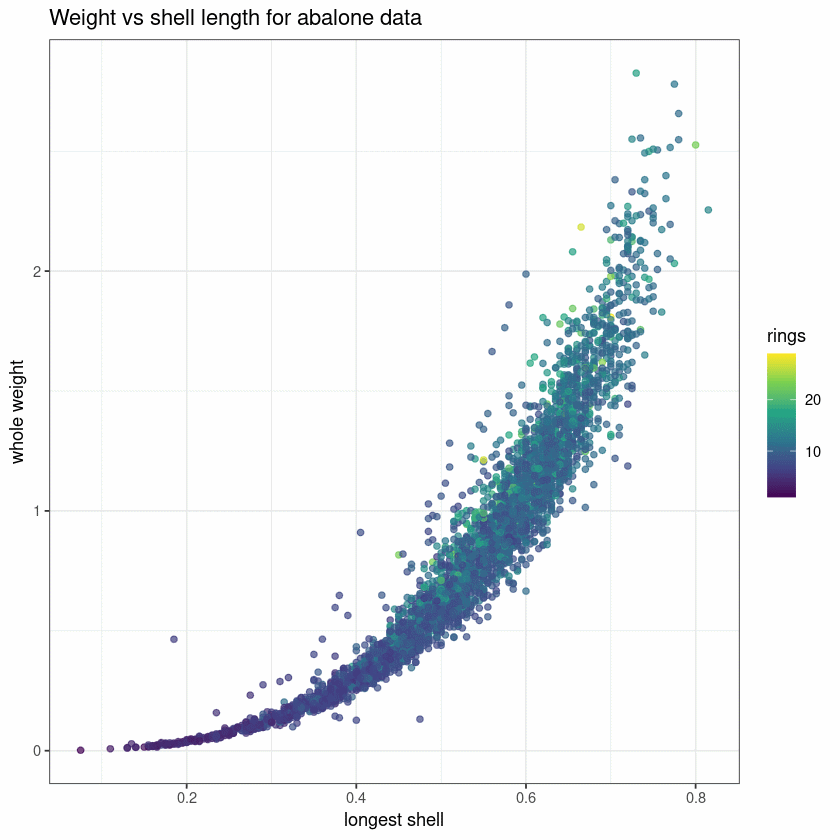

```r
# Plot weight vs shell length
plot <- ggplot(
  abalone,
  aes(x = longest_shell, y = whole_weight, col = rings)
) +
  geom_point(alpha = 0.7) +
  scale_color_viridis_c() +
  theme_bw() +
  labs(
    x = "Longest shell",
    y = "Whole weight",
    title = "Weight vs shell length for abalone data"
  )
print(plot)
```

**Python**

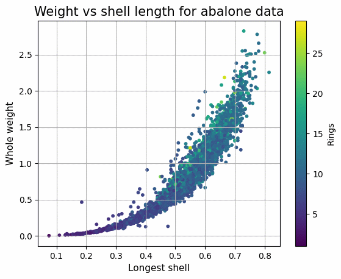

```python
plt.grid(True)
plt.scatter(
    abalone.longest_shell, abalone.whole_weight, s=10, c=abalone.rings, cmap="viridis"
)
plt.colorbar(label="Rings")  # add color bar
# title & label axes
plt.title("Weight vs shell length for abalone data", size=15)
plt.xlabel("Longest shell", size=11)
plt.ylabel("Whole weight", size=11)
plt.show()
```

We see that weight scales exponentially with shell length and that larger/heavier animals tend to have more rings.

2. Using `mlr3`/`sklearn`, fit a linear regression model to the data.

**Solution**

**R**

```r
# Specify regression task
task_abalone <- TaskRegr$new(
  id = "abalone",
  backend = abalone,
  target = "rings"
)
task_abalone

# Set up LM, train (by default, the target will be regressed on all features,
# i.e., target ~ .)
learner_lm <- mlr3::lrn("regr.lm")
print("Model before training:")
learner_lm$model

# Train and predict
learner_lm$train(task_abalone)
print("Model after training:")
learner_lm$model
pred_lm <- learner_lm$predict(task_abalone)

# Inspect predictions
print("Predictions:")
pred_lm
```

```
<TaskRegr:abalone> (4177 x 3)
* Target: rings
* Properties: -
* Features (2):
  - dbl (2): longest_shell, whole_weight
```

```
[1] "Model before training:"
```

```
[1] "Model after training:"
```

```
Call:
stats::lm(formula = task$formula(), data = task$data())

Coefficients:
  (Intercept)  longest_shell   whole_weight
        3.431         10.582          1.155
```

```
[1] "Predictions:"
```

```
<PredictionRegr> for 4177 observations:
    row_ids truth  response
          1    15  8.840042
          2     7  7.395659
          3     9  9.821995
---
       4175     9 11.139128
       4176    10 11.309553
       4177    12 13.195460
```

**Python**

```python
x_lm = abalone.iloc[:, 0:2].values
y_lm = abalone.rings
lm = LinearRegression().fit(x_lm, y_lm)
pred_lm = lm.predict(x_lm)
results_dic = {"prediction": pred_lm, "truth": y_lm}
results = pd.DataFrame(results_dic)
results.head()
```

|  | prediction | truth |
| --- | --- | --- |
| 0 | 8.840042 | 15 |
| 1 | 7.395659 | 7 |
| 2 | 9.821995 | 9 |
| 3 | 8.683616 | 10 |
| 4 | 7.160333 | 7 |

3. A key advantage of the linear model is that its parameters are directly interpretable. Read off the fitted coefficients and interpret the effect of `longest_shell` on the predicted number of rings.

**Solution**

The fitted linear model reads
$$\hat{f}(\mathbf{x}) = 3.43 + 10.58 \cdot x_{\text{shell}} + 1.16 \cdot x_{\text{weight}}.$$

The coefficient of `longest_shell` ($\approx 10.58$) is the *marginal effect* of this feature: increasing `longest_shell` by one unit – while holding `whole_weight` fixed – increases the predicted number of rings (i.e., the estimated age) by about $10.58$. Both coefficients are positive, matching our observation from a) that larger and heavier animals tend to have more rings. Note that `longest_shell` only ranges from roughly $0.1$ to $0.8$, so a full-unit change is large relative to the observed data.

**R**

```r
# The fitted linear model is directly interpretable via its coefficients:
coef(learner_lm$model)
```

[output not shown]

**Python**

```python
# The fitted linear model is directly interpretable via its coefficients:
print("Intercept:", lm.intercept_)
print("Coefficients (longest_shell, whole_weight):", lm.coef_)
```

[output not shown]

4. Compare the fitted and observed targets visually.

   **R Hint**

   Use `$autoplot()` from `mlr3viz`.

**Solution**

**R**

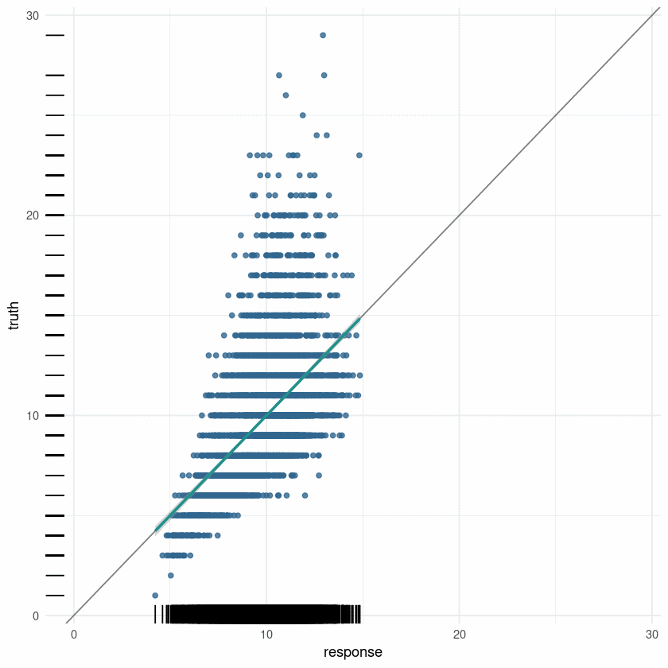

```r
# Get nice visualization with a one-liner
mlr3viz::autoplot(pred_lm) +
  xlim(c(0, max(abalone$rings)))
```

**Python**

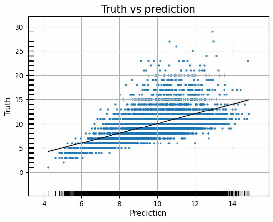

```python
plt.grid(True)
sns.regplot(
    x=pred_lm,
    y=y_lm,
    ci=95,
    scatter_kws={"s": 5},
    line_kws={"color": "black", "linewidth": 1},
)
sns.rugplot(x=pred_lm, y=y_lm, height=0.025, color="k")
# title & label axes
plt.title("Truth vs prediction", size=15)
plt.xlabel("Prediction", size=11)
plt.ylabel("Truth", size=11)
plt.show()
```

We see a scatterplot of prediction vs true values, where the small bars along the axes (a so-called rugplot) indicate the number of observations that fall into this area. As we might have suspected from the first plot, the underlying relationship is not exactly linear (ideally, all points and the resulting line should lie on the diagonal). With a linear model we tend to underestimate the response.

5. Assess the model’s training loss in terms of MAE.

   **Hint**

   **R**

   Call `$score()`, which accepts different `mlr_measures`, on the prediction object.

   **Python**

   Call `from sklearn.metrics import mean_absolute_error`.

**Solution**

**R**

```r
# Define MAE metric
mae <- msr("regr.mae")

# Assess performance (MSE by default)
round(pred_lm$score(), 4)
round(pred_lm$score(mae), 4)
```

**regr.mse:** 7.1255

**regr.mae:** 1.9507

**Python**

```python
mae = mean_absolute_error(pred_lm, y_lm)
print(f"{mae:.4f}")
```

```
1.9507
```